# Data Mining Final Project B: Criminal Recidivism Prediction

Namratha N., Mehak Sikka, Malvika Singh, Sanjana Panicker

Submitted: May 7, 2019

#Exploratory Data Analysis

### Preamble: Loading packages and data

```r
library(dplyr)
```

```r
library(ggplot2)
library(knitr)
```

### Loading COMPAS 2 years data

```
##   id               name  first        last compas_screening_date  sex
## 1  1   miguel hernandez miguel   hernandez            2013-08-14 Male
## 2  3        kevon dixon  kevon       dixon            2013-01-27 Male
## 3  4           ed philo     ed       philo            2013-04-14 Male
## 4  5        marcu brown  marcu       brown            2013-01-13 Male
## 5  6 bouthy pierrelouis bouthy pierrelouis            2013-03-26 Male
## 6  7       marsha miles marsha       miles            2013-11-30 Male
##          dob age         age_cat             race juv_fel_count
## 1 1947-04-18  69 Greater than 45            Other             0
## 2 1982-01-22  34         25 - 45 African-American             0
## 3 1991-05-14  24    Less than 25 African-American             0
## 4 1993-01-21  23    Less than 25 African-American             0
## 5 1973-01-22  43         25 - 45            Other             0
## 6 1971-08-22  44         25 - 45            Other             0
##   decile_score juv_misd_count juv_other_count priors_count
```

[output cut: 76 more lines]

```
## [1] "The number of rows in data  7214"
```

```
## [1] "The dimension of data  7214" "The dimension of data  53"
```

## There are a number of reasons remove rows because of missing data: (Referenced from propublica/compas-analysis on github)

##If the charge date of a defendants Compas scored crime was not within 30 days from when the person was arrested, we assume that because of data quality reasons, that we do not have the right offense. ## Coded the recidivist flag – is_recid – to be -1 if we could not find a compas case at all. ##In a similar vein, ordinary traffic offenses – those with a c_charge_degree of ‘O’ – will not result in Jail time are removed (only two of them). ## Filtered the underlying data from Broward county to include only those rows representing people who had either recidivated in two years, or had at least two years outside of a correctional facility.

```r
df <- dplyr::select(raw_data, age, c_charge_degree, race, age_cat, score_text, sex, priors_count, days_b_screening_arrest, decile_score, is_recid, two_year_recid, c_jail_in, c_jail_out) %>%
        filter(days_b_screening_arrest <= 30) %>%
        filter(days_b_screening_arrest >= -30) %>%
        filter(is_recid != -1) %>%
        filter(c_charge_degree != "O") %>%
        filter(score_text != 'N/A')
nrow(df)
```

```
## [1] 6172
```

```r
library(knitr)
print(summary(df))   ##### Summarizing the entire dataset
```

```
##       age        c_charge_degree               race
##  Min.   :18.00   F:3970          African-American:3175
##  1st Qu.:25.00   M:2202          Asian           :  31
##  Median :31.00                   Caucasian       :2103
##  Mean   :34.53                   Hispanic        : 509
##  3rd Qu.:42.00                   Native American :  11
##  Max.   :96.00                   Other           : 343
##
##             age_cat      score_text       sex        priors_count
##  25 - 45        :3532   High  :1144   Female:1175   Min.   : 0.000
##  Greater than 45:1293   Low   :3421   Male  :4997   1st Qu.: 0.000
##  Less than 25   :1347   Medium:1607                 Median : 1.000
##                                                     Mean   : 3.246
##                                                     3rd Qu.: 4.000
##                                                     Max.   :38.000
##
##  days_b_screening_arrest  decile_score       is_recid
##  Min.   :-30.00          Min.   : 1.000   Min.   :0.0000
##  1st Qu.: -1.00          1st Qu.: 2.000   1st Qu.:0.0000
##  Median : -1.00          Median : 4.000   Median :0.0000
##  Mean   : -1.74          Mean   : 4.419   Mean   :0.4844
##  3rd Qu.: -1.00          3rd Qu.: 7.000   3rd Qu.:1.0000
##  Max.   : 30.00          Max.   :10.000   Max.   :1.0000
##
##  two_year_recid                 c_jail_in                  c_jail_out
##  Min.   :0.0000   2013-01-01 01:31:55:   1   2013-09-14 05:58:00:   3
##  1st Qu.:0.0000   2013-01-01 03:16:15:   1   2013-02-06 10:01:51:   2
##  Median :0.0000   2013-01-01 03:28:03:   1   2013-08-13 10:05:00:   2
##  Mean   :0.4551   2013-01-01 04:17:22:   1   2013-09-14 05:54:00:   2
##  3rd Qu.:1.0000   2013-01-01 04:29:04:   1   2013-09-23 08:25:00:   2
##  Max.   :1.0000   2013-01-01 05:08:53:   1   2013-11-09 02:08:17:   2
##                   (Other)            :6166   (Other)            :6159
```

```r
xtabs(~ sex + race, data=df) ####### Providing numbers in each category
```

```
##         race
## sex      African-American Asian Caucasian Hispanic Native American Other
##   Female              549     2       482       82               2    58
##   Male               2626    29      1621      427               9   285
```

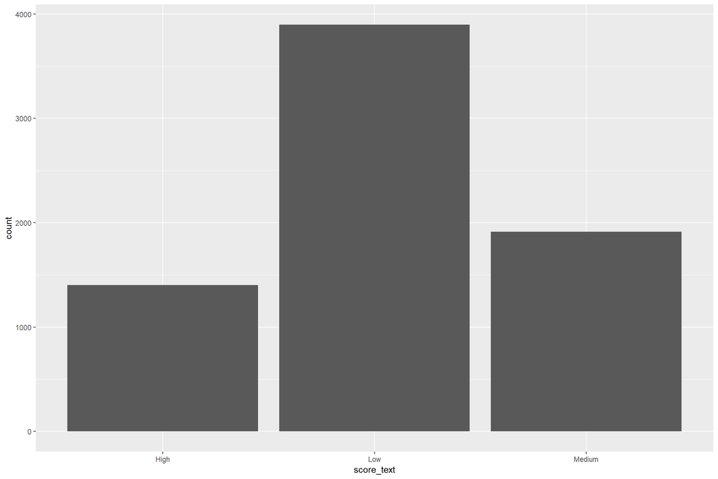

```r
ggplot(data = raw_data) +
  geom_bar(mapping = aes(x = score_text))
```

*The previous bar graph shows the distribution of people in High, Medium and Low Risk crimes, with most of the people being categorised in the low risk crimes.*

*The following correlation plot shows correlation between different variables. This is helpful so as to shortlist predictors that we would want to use for our models subsequently.*

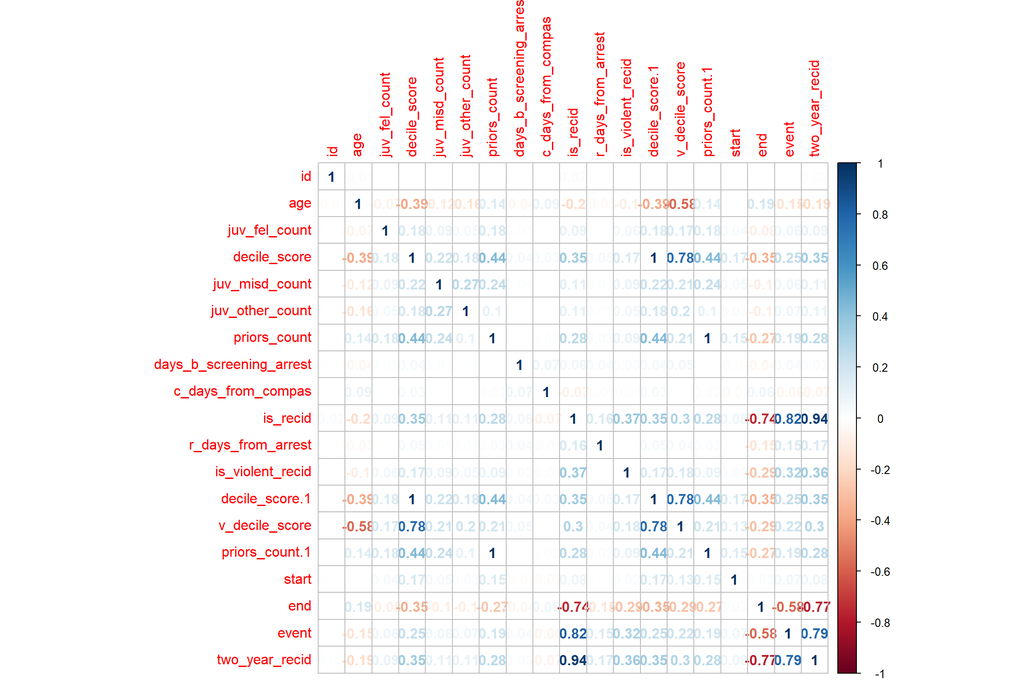

```r
library(corrplot)
# correlations
nums <- unlist(lapply(raw_data, is.numeric))
df <- raw_data[ , nums]
df[is.na(df)] <- -1        ###### Replaced NAs in dataset with -1 indicating missing value #
correlations<- cor(df)
corrplot(correlations,method = "number")  #blue indicates positive correlation, red indicates negative
```

*As we can see, there is strong positive correlation between is_recid and two_year_recid indicating that if a person commits a crime for the first time, they are likely to commit a crime for another year too.*

### Box-plot for Race vs Decile Score

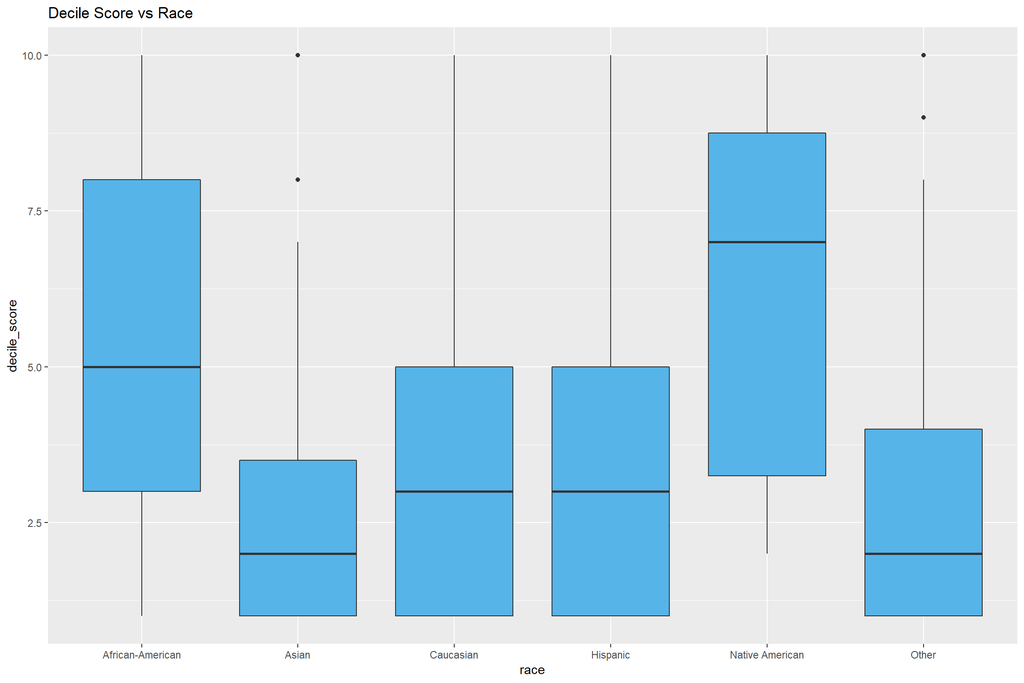

```r
cbPalette <- c("#999999", "#E69F00", "#56B4E9", "#009E73", "#F0E442", "#0072B2", "#D55E00", "#CC79A7")

options(scipen = 4)

qplot(data = raw_data, x = race, y = decile_score, fill = I(cbPalette[3]), geom = "boxplot",main = "Decile Score vs Race")
```

*As we observe from the plot, African-American and native americans have higher decile scores as compared to other ethnicities. This indicates a potential bias in the scoring pattern.*

### Variation of Decile Score with Age

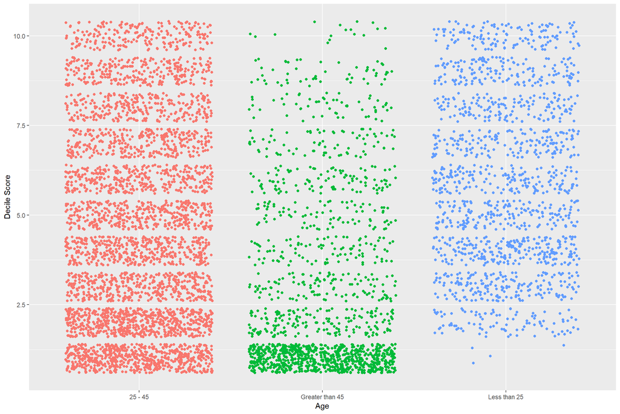

```r
ggplot(data = raw_data, aes(x = age_cat, y = decile_score,color=as.factor(age_cat))) +
  geom_jitter() +
  stat_smooth(method = "lm", col = "red")+guides(color=FALSE)+xlab("Age")+ylab("Decile Score")
```

*There is higher density of population between the age group 25-45 that has a higher decile score as compared to the other age groups.*

### Analysing prior count for various ethnicities

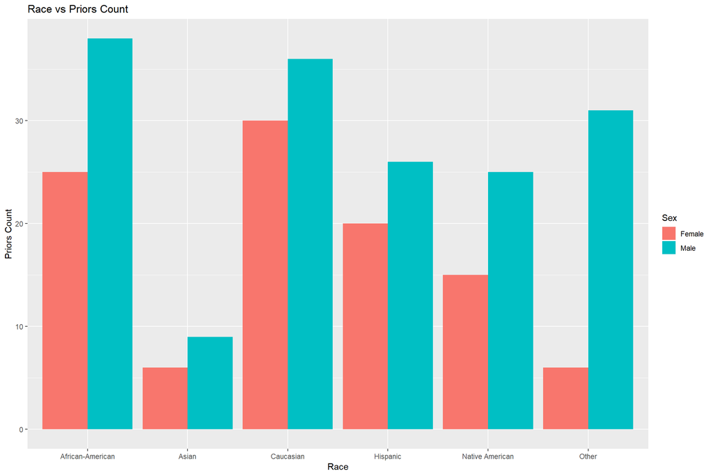

```r
ggplot(raw_data, aes(x=race, y=priors_count, fill = sex)) + geom_bar(stat="identity",position = "dodge") + ggtitle("Race vs Priors Count") + xlab("Race") + ylab("Priors Count") + guides(fill = guide_legend(title = "Sex"))
```

### Analysing Violent Recidivism

```r
###### Analysing Violent Recidivism ########
raw_data_violent <- read.csv("./compas-scores-two-years-violent.csv")
nrow(raw_data_violent)
```

```
## [1] 4743
```

```r
head(raw_data_violent)
```

```
##   id               name  first        last compas_screening_date  sex
## 1  1   miguel hernandez miguel   hernandez            2013-08-14 Male
## 2  3        kevon dixon  kevon       dixon            2013-01-27 Male
## 3  5        marcu brown  marcu       brown            2013-01-13 Male
## 4  6 bouthy pierrelouis bouthy pierrelouis            2013-03-26 Male
## 5  7       marsha miles marsha       miles            2013-11-30 Male
## 6  9     steven stewart steven     stewart            2013-08-30 Male
##          dob age         age_cat             race juv_fel_count
## 1 1947-04-18  69 Greater than 45            Other             0
## 2 1982-01-22  34         25 - 45 African-American             0
## 3 1993-01-21  23    Less than 25 African-American             0
## 4 1973-01-22  43         25 - 45            Other             0
## 5 1971-08-22  44         25 - 45            Other             0
## 6 1973-02-25  43         25 - 45            Other             0
##   decile_score juv_misd_count juv_other_count priors_count
```

[output cut: 76 more lines]

```r
### Filtering from COMPAS dataset using code from github, propublica ######
df1 <- dplyr::select(raw_data_violent, age, c_charge_degree, race, age_cat, v_score_text, sex, priors_count,days_b_screening_arrest, v_decile_score, is_recid, two_year_recid) %>%
        filter(days_b_screening_arrest <= 30) %>%
        filter(days_b_screening_arrest >= -30) %>%
        filter(is_recid != -1) %>%
        filter(c_charge_degree != "O") %>%
        filter(v_score_text != 'N/A')
nrow(df1)
```

```
## [1] 4020
```

```r
summary(df1)   ##### Summarizing the entire dataset
```

```
##       age        c_charge_degree               race
##  Min.   :18.00   F:2413          African-American:1918
##  1st Qu.:26.00   M:1607          Asian           :  26
##  Median :33.00                   Caucasian       :1459
##  Mean   :35.74                   Hispanic        : 355
##  3rd Qu.:44.00                   Native American :   7
##  Max.   :83.00                   Other           : 255
##             age_cat     v_score_text      sex        priors_count
##  25 - 45        :2300   High  : 279   Female: 841   Min.   : 0.000
##  Greater than 45: 954   Low   :2913   Male  :3179   1st Qu.: 0.000
##  Less than 25   : 766   Medium: 828                 Median : 1.000
##                                                     Mean   : 2.446
##                                                     3rd Qu.: 3.000
##                                                     Max.   :38.000
##  days_b_screening_arrest v_decile_score      is_recid
##  Min.   :-30.000         Min.   : 1.000   Min.   :0.0000
##  1st Qu.: -1.000         1st Qu.: 1.000   1st Qu.:0.0000
##  Median : -1.000         Median : 3.000   Median :0.0000
##  Mean   : -1.905         Mean   : 3.265   Mean   :0.2072
##  3rd Qu.: -1.000         3rd Qu.: 5.000   3rd Qu.:0.0000
##  Max.   : 30.000         Max.   :10.000   Max.   :1.0000
##  two_year_recid
##  Min.   :0.0000
##  1st Qu.:0.0000
##  Median :0.0000
##  Mean   :0.1622
##  3rd Qu.:0.0000
##  Max.   :1.0000
```

```r
xtabs(~ sex + race, data=df1) ####### Providing numbers in each category
```

```
##         race
## sex      African-American Asian Caucasian Hispanic Native American Other
##   Female              393     1       336       61               0    50
##   Male               1525    25      1123      294               7   205
```

### Correlation Plot for 2 years violent data

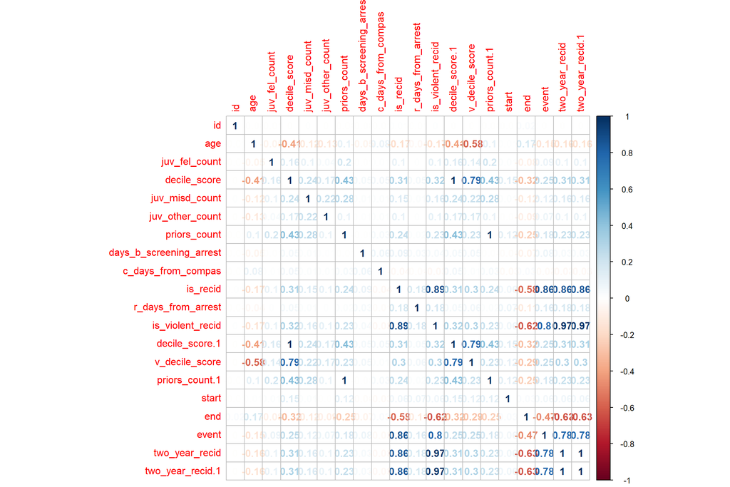

```r
library(corrplot)
# correlations
nums1 <- unlist(lapply(raw_data_violent, is.numeric))
df_corr <- raw_data_violent[ , nums1]
df_corr[is.na(df_corr)] <- -1        ###### Replaced NAs in dataset with -1 indicating missing value #
correlations_v<- cor(df_corr)
corrplot(correlations_v,method = "number")  #blue indicates positive correlation, red indicates negative
```

*High positive correlation again observed between 1 year and 2 year recidivism rates indicating that if an individual is convicted of a violent crime in the first year, they are likely to reoffend. Violent decile score also positively correlated with the decile score for this reason.*

### Box Plot Visualisation for Violent 2 year data

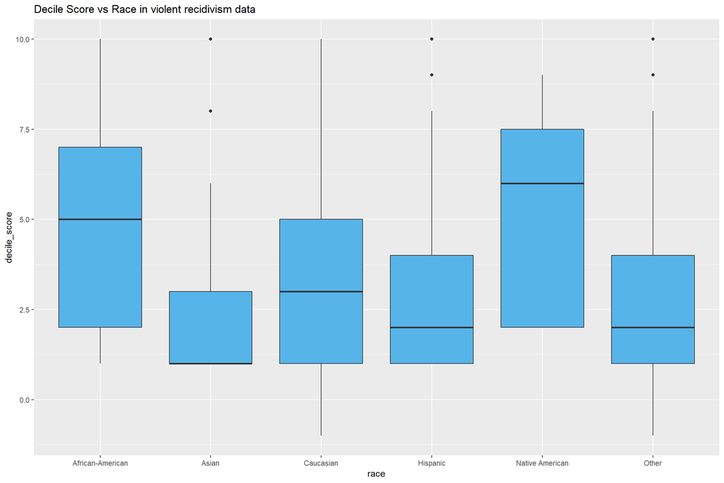

```r
qplot(data = raw_data_violent, x = race, y = decile_score, fill = I(cbPalette[3]), geom = "boxplot",main = "Decile Score vs Race in violent recidivism data")
```

*Again, Native Americans and African-Americans have higher decile scores as compared to other ethnicities.*

### Race vs Priors Count for different ethnicities for violent Recidivism

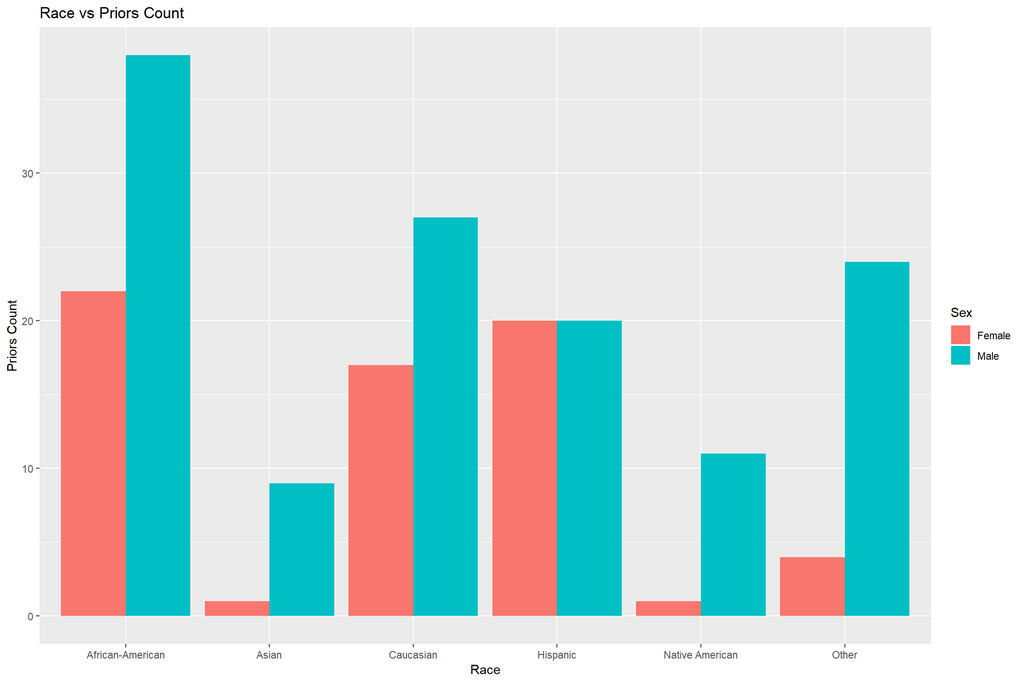

```r
## Referenced Stackoverflow and Statistical tools for high throughput data analysis website for ggplot function incorporating multiple categories for both datasets
ggplot(raw_data_violent, aes(x=race, y=priors_count, fill = sex)) + geom_bar(stat="identity",position = "dodge") + ggtitle("Race vs Priors Count") + xlab("Race") + ylab("Priors Count") + guides(fill = guide_legend(title = "Sex"))
```

*As seen from the above plot, African-American males have highest occurrence of prior counts than other categories.* ##### Comparing two year and two year violent recidivism datasets ####

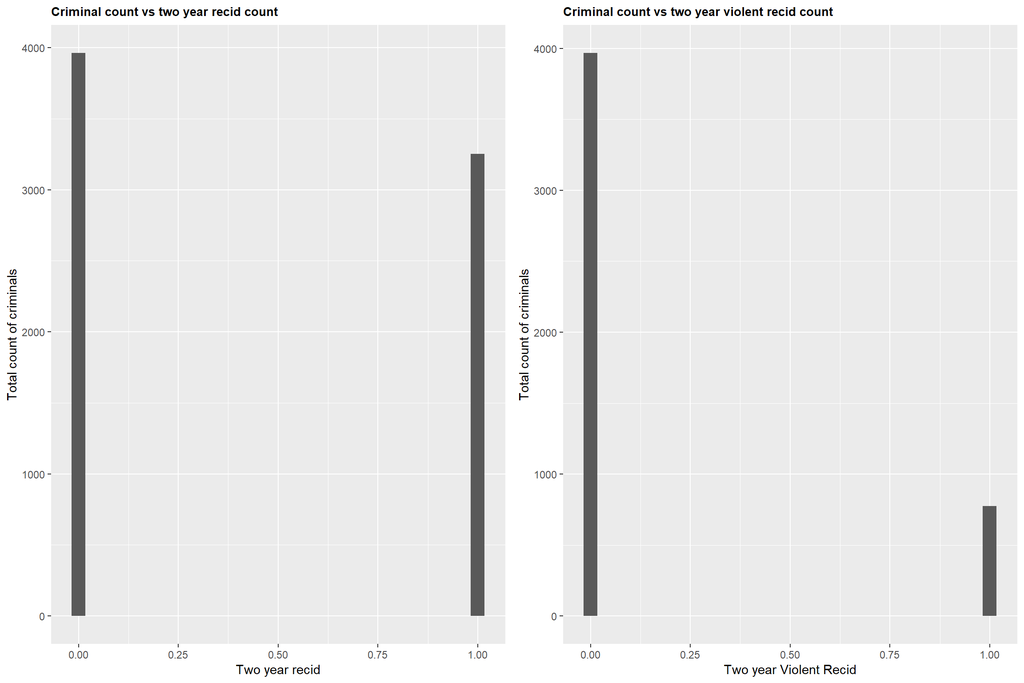

```r
library(ggplot2)
library(gridExtra)
plot1<- qplot(raw_data$two_year_recid, xlab = "Two year recid", ylab = "Total count of criminals") + ggtitle("Criminal count vs two year recid count") + theme(plot.title = element_text(size = 10, face = "bold"))

plot2 <- qplot(raw_data_violent$two_year_recid, xlab = "Two year Violent Recid", ylab = "Total count of criminals") + ggtitle("Criminal count vs two year violent recid count") + theme(plot.title = element_text(size = 10, face = "bold"))

grid.arrange(plot1, plot2, ncol=2)
```

*The number of people who recivid in the non-violent dataset is higher than the violent dataset. This indicates that people commiting a non-violent crime once are more likely to commit a non-violent crime than the people commiting violent crime repeating the same.*

```r
if (!require(rpart)) {install.packages("rpart"); library(rpart)}
if (!require(rattle)) {install.packages("rattle"); library(rattle)}
```

```r
if (!require(rpart.plot)) {install.packages("rpart.plot"); library(rpart.plot)}
if (!require(RColorBrewer)) {install.packages("RColorBrewer"); library(RColorBrewer)}
if(!require(pracma)) {install.packages("pracma"); library(pracma)}
if (!require(pROC)) {install.packages("pROC"); library(pROC)}
if(!require(ROCR)) {install.packages("ROCR")}; library(ROCR)
library(dplyr)
library(ggplot2)
library(randomForest)
criminal_data <- read.csv("./compas-scores-two-years.csv")
nrow(criminal_data)
```

```
## [1] 7214
```

```r
df <- dplyr::select(criminal_data, id, age, age_cat, race, juv_fel_count, juv_misd_count, juv_other_count, c_charge_degree, race, score_text, sex, priors_count, r_charge_degree, type_of_assessment, in_custody, out_custody, days_b_screening_arrest, is_recid, two_year_recid, c_jail_in, c_jail_out) %>%
        filter(days_b_screening_arrest <= 30) %>%
        filter(days_b_screening_arrest >= -30) %>%
        filter(is_recid != -1) %>%
        filter(c_charge_degree != "O") %>%
        filter(r_charge_degree != "O") %>%
        filter(score_text != 'N/A')

df$sex= as.factor(df$sex)
df$age_cat=as.factor(df$age_cat)
df$race=as.factor(df$race)
df$c_charge_degree=as.factor(df$c_charge_degree)
df$race=as.factor(df$race)

nrow(df)
```

```
## [1] 6172
```

```r
df$length_of_stay <- as.numeric(as.Date(df$c_jail_out) - as.Date(df$c_jail_in))
#cor(df$length_of_stay, df$decile_score)

summary(df$age_cat)
```

```
##         25 - 45 Greater than 45    Less than 25
##            3532            1293            1347
```

```r
summary(df$race)
```

```
## African-American            Asian        Caucasian         Hispanic
##             3175               31             2103              509
##  Native American            Other
##               11              343
```

```r
summary(df$score_text)
```

```
##   High    Low Medium
##   1144   3421   1607
```

```r
xtabs(~ sex + race, data=df)
```

```
##         race
## sex      African-American Asian Caucasian Hispanic Native American Other
##   Female              549     2       482       82               2    58
##   Male               2626    29      1621      427               9   285
```

```r
summary(df$sex)
```

```
## Female   Male
##   1175   4997
```

```r
paste("Number of criminials with two year recidivism: ", nrow(filter(df, two_year_recid == 1)))
```

```
## [1] "Number of criminials with two year recidivism:  2809"
```

```r
paste("Percentage of criminials with two year recidivism: ", nrow(filter(df, two_year_recid == 1)) / nrow(df) * 100)
```

```
## [1] "Percentage of criminials with two year recidivism:  45.5119896305898"
```

###Introduction and Goal Setting

*In this criminal recidivism project we aim to come up with a model to aid and assist judges in making decisions to decide how likely a criminal is to commit a crime again. Our goal in this project is to come up with a model which has a high specificity that is a good true negative rate.*

*Specificity aka True Negative Rate* *(TNR)=#observations correctly classified as non-events/#observations that did not have the event* *=T N/(T N + F P) A classifier with high Specificity is desirable here because in our opinion, False Positives (extending the conviction for a person who is not likely to commit a crime) are more costly than False Negatives (releasing a person who is likely to commit a crime again). We have taken in cosideration the specificity-sensitivity trade off.*

##Feature Selection

*The original compas file had 53 variables.However, in order to proceed with the analysis we decided to drop some variables. We explored the data on the CSV file and decided which variables to use. We started out by eliminating the obvious variables. For example, id, name, dob variables we realised would have no bearing on the outcome of the recidivism prediction.We then removed the other identity providing variables like v_case_number, r_case_number, vr_case_number. We then removed the date variables as they too would not be useful in predicting recidivism. This resulted in us eliminating 19 variables. After that, we used our correlation plots. There was a obviously high correlation between age and age-category and it made more sense to use age category as we could then make age a categorical variable. We then removed the decile score values and other compas parameters as they were the output of compas, and if we were to make a model alternative to Compas, using Compas’s output would make little sense. We now had removed 27 variables. Upon running a Random Forest model , we realised that we could not use the r_charge_degree and r_charge_desc as there was a very high number of missing values in the data. We this eliminated all the charge degrees and their description. We eliminated the violent_recidivism parameters as well as we are making a separate model to predict violent recidivism. This left us with 12 variables to work with.*

*We started out my making a custom built function which we would use through our project to give us the confusion matrix and performance metrics of the different models that we fit for different data. The parameters that we pass to this model are the results from our model, the actual predicted values, the cutoff values and the type of parameters that we need for the function to evaluate.*

```r
classMetrics <- function(score, y, cutoff,
                         type = c("all", "accuracy", "sensitivity",
                                  "specificity", "ppv", "npv", "precision",
                                  "recall")) {

# This command throws an error if the user specifies a "type" that
# isn't supported by this function
type <- match.arg(type, several.ok = TRUE)
our_result<-numeric()
for(i in 1:length(score)){
  if(score[i]>cutoff){
    our_result<-c(our_result,1) #if greater then cutoff 1
  }
  else{
    our_result<-c(our_result,0) #if lesser than or equal to cutoff then 0
  }
}
#We shall now create the confusion matrix
y.fakefactor<-factor(y) #Converting y into factors
or.factor<-factor(our_result) #Converting our_result into factors
x=table(round(our_result), y)
names(dimnames(x)) <- c("predicted", "actual")

ym<-as.matrix(x)
new_mat <- matrix(0,nrow=2,ncol=2)
# 'new_mat' rows getting filled with `mat` values
if(nrow(ym)==1){
new_mat[1,] <- ym

ym=new_mat
}
sum(ym)
 # print("y[2,1]")
 # print(ym[2,1])
acc<-(ym[2,2]+ym[1,1])/sum(ym)
sensi<-ym[2,2]/(ym[2,2]+ym[1,2])
spec<-ym[1,1]/(ym[1,1]+ym[2,1])
ppv<-ym[2,2]/(ym[2,2]+ym[2,1])
npv<- ym[1,1]/(ym[1,1]+ym[1,2])
prec<-ym[2,2]/(ym[2,2]+ym[2,1])
recall<-ym[2,2]/(ym[2,2]+ym[1,2])

perfv<-c(acc,sensi,spec,ppv,npv,prec,recall)
perfdf<-data.frame(perfv) #Convert the vector into a dataframe
rownames(perfdf) <- c("accuracy", "sensitivity",
                                  "specificity", "ppv", "npv", "precision",
                                  "recall")

perf=data.frame()

names(perfdf) <- "values"
library(pracma)
if(strcmp(type[1],"all")) {
ret_list<-  list(conf.mat = as.matrix(x), perf = perfdf)
}else{

ret_list<-list(conf.mat = as.matrix(x), perf = subset(perfdf, subset=rownames(perfdf) %in% type))
}

return(ret_list)
}

# Return two objects: Use a list
```

## Building Models for Criminal Recidivism

```r
#RANDOM FOREST MODEL
sizeraw = nrow(df)
sample = sample.int(2, size=sizeraw, prob=c(.7,.3), replace=TRUE)
trainsample=(sample==1)     # put 60% of the observations in the training sample
predsample=(sample==2)
is.na(df) <-df==''
df[df == ""] <- NA
criminal.rf <- randomForest(two_year_recid ~ sex  + age_cat + race + juv_fel_count + juv_misd_count + juv_other_count +
                            priors_count + c_charge_degree + type_of_assessment + race  + days_b_screening_arrest,
                            data=df[trainsample,], method = "class",importance=TRUE,na.action = na.roughfix)
importance(criminal.rf)
```

```
##                            %IncMSE IncNodePurity
## sex                      24.458885      14.95739
## age_cat                  64.816127      42.64095
## race                     22.653122      29.71247
## juv_fel_count             7.489551       8.90295
## juv_misd_count           10.862645      12.65460
## juv_other_count          21.921977      20.64347
## priors_count            103.948907     131.37204
## c_charge_degree          16.562086      12.77034
## type_of_assessment        0.000000       0.00000
## days_b_screening_arrest  11.579475      42.03533
```

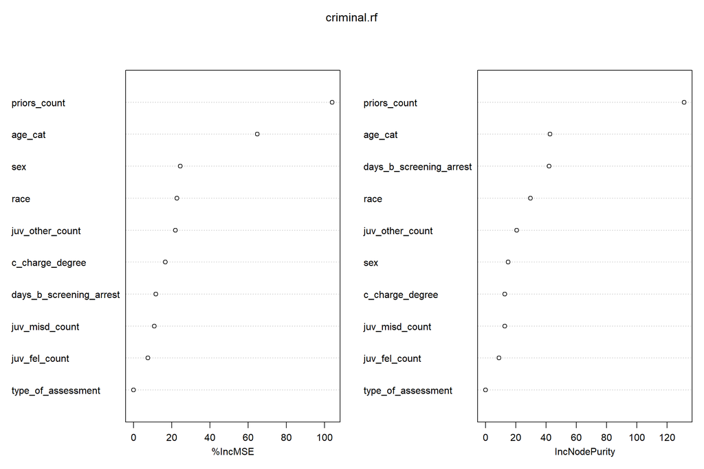

```r
varImpPlot (criminal.rf)
```

```r
criminal.pred = predict(criminal.rf, newdata=df[predsample,], type="response")
criminal.pred[1:10]
```

```
##         4         7         8        10        16        22        23
## 0.1695273 0.2152895 0.3368096 0.2512238 0.6431461 0.4790398 0.4277359
##        27        30        40
## 0.2747738 0.1995609 0.2747738
```

```r
length(criminal.pred)
```

```
## [1] 1861
```

```r
length(df[predsample,]$age)
```

```
## [1] 1861
```

```r
#popener[1:10]
#trainsample
length(criminal.rf)
```

```
## [1] 18
```

```r
length(criminal.pred)
```

```
## [1] 1861
```

```r
nrow(df[predsample,])
```

```
## [1] 1861
```

```r
#res2=classMetrics(popener,marketing.test$y,0.5,type="all")
rf.perform.measure<-classMetrics(criminal.pred,df[predsample,]$two_year_recid, 0.5, type = "all")
rf.perform.measure$conf.mat
```

```
##          actual
## predicted   0   1
##         0 784 396
##         1 221 460
```

```r
rf.perform.measure$perf
```

```
##                values
## accuracy    0.6684578
## sensitivity 0.5373832
## specificity 0.7800995
## ppv         0.6754772
## npv         0.6644068
## precision   0.6754772
## recall      0.5373832
```

*Reference: https://www.brighthubpm.com/project-planning/106000-advantages-of-decision-tree-analysis/*

```r
#DECISION TREE MODEL
library(rpart)
criminal.tree.full <- rpart(two_year_recid ~ sex + age_cat + race + juv_fel_count + juv_misd_count + juv_other_count +
                     priors_count +c_charge_degree+type_of_assessment+race+days_b_screening_arrest,
                     data =df[predsample,],control = rpart.control(minsplit=100, cp=0.002))
criminal.tree.full$cptable
```

```
##             CP nsplit rel error    xerror        xstd
## 1  0.077974927      0 1.0000000 1.0020915 0.003762595
## 2  0.036483829      1 0.9220251 0.9396687 0.013154970
## 3  0.013291827      2 0.8855412 0.9100764 0.014919433
## 4  0.011709448      3 0.8722494 0.8966869 0.015451033
## 5  0.008725955      4 0.8605400 0.8885908 0.015695738
## 6  0.007715439      5 0.8518140 0.8888420 0.016012381
## 7  0.004532330      6 0.8440986 0.8755613 0.016476765
## 8  0.004012853      7 0.8395662 0.8761213 0.016832420
## 9  0.003698315      8 0.8355534 0.8722409 0.016913220
## 10 0.003204063      9 0.8318551 0.8703269 0.016909795
## 11 0.002713667     10 0.8286510 0.8672238 0.016881093
## 12 0.002000000     11 0.8259373 0.8618642 0.016947704
```

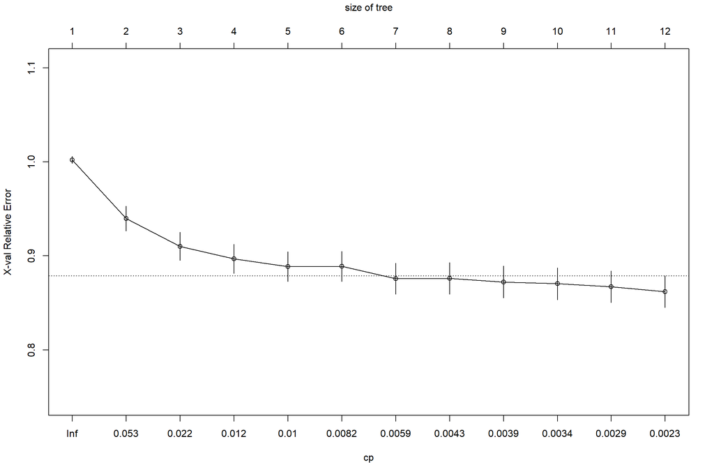

```r
plotcp(criminal.tree.full)
```

```r
###Finding the best CP using 1SE Rule
y=0
best_cp<-0
x=which.min(criminal.tree.full$cptable[,4])
for(i in 1:nrow(criminal.tree.full$cptable)){
  if(criminal.tree.full$cptable[i,4]<criminal.tree.full$cptable[x,4]+criminal.tree.full$cptable[x,5]){
    y=criminal.tree.full$cptable[i,4]
    best_cp=criminal.tree.full$cptable[i,"CP"]
    print(criminal.tree.full$cptable[i,"CP"])
    break
  }
}
```

```
## [1] 0.00453233
```

```r
library(partykit)
criminal.tree.pruned=prune(criminal.tree.full, cp = best_cp)
print(criminal.tree.pruned)
```

```
## n= 1861
##
## node), split, n, deviance, yval
##       * denotes terminal node
##
##  1) root 1861 462.267600 0.4599678
##    2) priors_count< 2.5 1186 271.555600 0.3549747
##      4) age_cat=25 - 45,Greater than 45 850 171.360000 0.2800000
##        8) priors_count< 0.5 460  75.380430 0.2065217 *
##        9) priors_count>=0.5 390  90.566670 0.3666667 *
##      5) age_cat=Less than 25 336  83.330360 0.5446429
##       10) priors_count< 0.5 193  47.875650 0.4559585 *
##       11) priors_count>=0.5 143  31.888110 0.6643357 *
##    3) priors_count>=2.5 675 154.666700 0.6444444
##      6) priors_count< 9.5 500 121.128000 0.5880000
##       12) days_b_screening_arrest< -4.5 37   7.297297 0.2702703 *
##       13) days_b_screening_arrest>=-4.5 463 109.797000 0.6133909 *
##      7) priors_count>=9.5 175  27.394290 0.8057143 *
```

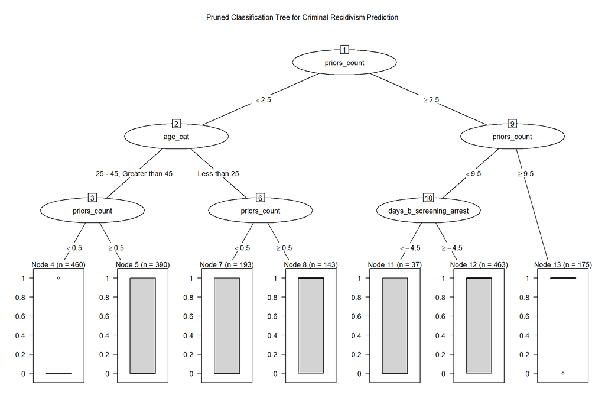

```r
criminal.tree.party <- as.party(criminal.tree.pruned)
plot(criminal.tree.party, gp=gpar(fontsize = 10), uniform=TRUE,
   main="Pruned Classification Tree for Criminal Recidivism Prediction")
```

```r
print(criminal.tree.party)
```

```
##
## Model formula:
## two_year_recid ~ sex + age_cat + race + juv_fel_count + juv_misd_count +
##     juv_other_count + priors_count + c_charge_degree + type_of_assessment +
##     race + days_b_screening_arrest
##
## Fitted party:
## [1] root
## |   [2] priors_count < 2.5
## |   |   [3] age_cat in 25 - 45, Greater than 45
## |   |   |   [4] priors_count < 0.5: 0.207 (n = 460, err = 75.4)
## |   |   |   [5] priors_count >= 0.5: 0.367 (n = 390, err = 90.6)
## |   |   [6] age_cat in Less than 25
## |   |   |   [7] priors_count < 0.5: 0.456 (n = 193, err = 47.9)
## |   |   |   [8] priors_count >= 0.5: 0.664 (n = 143, err = 31.9)
## |   [9] priors_count >= 2.5
## |   |   [10] priors_count < 9.5
## |   |   |   [11] days_b_screening_arrest < -4.5: 0.270 (n = 37, err = 7.3)
## |   |   |   [12] days_b_screening_arrest >= -4.5: 0.613 (n = 463, err = 109.8)
## |   |   [13] priors_count >= 9.5: 0.806 (n = 175, err = 27.4)
##
## Number of inner nodes:    6
## Number of terminal nodes: 7
```

```r
is.recid.predict = predict(criminal.tree.pruned,newdata=df[predsample,])
tree.perform.measure=classMetrics(is.recid.predict,df[predsample,]$two_year_recid,0.3,type="all")
tree.perform.measure$conf.mat
```

```
##          actual
## predicted   0   1
##         0 392 105
##         1 613 751
```

```r
tree.perform.measure$perf
```

```
##                values
## accuracy    0.6141859
## sensitivity 0.8773364
## specificity 0.3900498
## ppv         0.5505865
## npv         0.7887324
## precision   0.5505865
## recall      0.8773364
```

```r
sizeraw = nrow(df)
sample = sample.int(2, size=sizeraw, prob=c(.7,.3), replace=TRUE)
trainsample=(sample==1)     # put 60% of the observations in the training sample
predsample=(sample==2)


df_cmps1 <- mutate(df, crime_factor = factor(c_charge_degree)) %>%
      mutate(age_factor = as.factor(age_cat)) %>%
      within(age_factor <- relevel(age_factor, ref = 1)) %>%
      mutate(race_factor = factor(race)) %>%
      within(race_factor <- relevel(race_factor, ref = 3)) %>%
      mutate(gender_factor = factor(sex, labels= c("Female","Male"))) %>%
      within(gender_factor <- relevel(gender_factor, ref = 2)) %>%
      mutate(score_factor = factor(score_text != "Low", labels = c("LowScore","HighScore")))
model <- glm(score_factor ~ gender_factor + age_factor + race_factor +
                            priors_count + crime_factor + two_year_recid, family="binomial", data=df_cmps1[trainsample,])
summary(model)
```

```
##
## Call:
## glm(formula = score_factor ~ gender_factor + age_factor + race_factor +
##     priors_count + crime_factor + two_year_recid, family = "binomial",
##     data = df_cmps1[trainsample, ])
##
## Deviance Residuals:
##     Min       1Q   Median       3Q      Max
## -2.9737  -0.8066  -0.3350   0.8309   2.5845
##
## Coefficients:
##                             Estimate Std. Error z value Pr(>|z|)
## (Intercept)                 -1.48564    0.09471 -15.686  < 2e-16 ***
## gender_factorFemale          0.22366    0.09548   2.343 0.019154 *
## age_factorGreater than 45   -1.36653    0.11885 -11.498  < 2e-16 ***
## age_factorLess than 25       1.35335    0.09019  15.006  < 2e-16 ***
## race_factorAfrican-American  0.47634    0.08270   5.760 8.41e-09 ***
## race_factorAsian            -0.16918    0.63695  -0.266 0.790537
## race_factorHispanic         -0.42455    0.15193  -2.794 0.005200 **
## race_factorNative American   1.14224    0.98418   1.161 0.245803
## race_factorOther            -0.82375    0.19001  -4.335 1.46e-05 ***
## priors_count                 0.26893    0.01334  20.161  < 2e-16 ***
## crime_factorM               -0.29586    0.07942  -3.725 0.000195 ***
## two_year_recid               0.57770    0.07641   7.560 4.02e-14 ***
## ---
## Signif. codes:  0 '***' 0.001 '**' 0.01 '*' 0.05 '.' 0.1 ' ' 1
##
## (Dispersion parameter for binomial family taken to be 1)
##
##     Null deviance: 5925.1  on 4307  degrees of freedom
## Residual deviance: 4344.9  on 4296  degrees of freedom
## AIC: 4368.9
##
## Number of Fisher Scoring iterations: 5
```

```r
#R standard confusion matrix
log.probs = predict(model, newdata = df_cmps1[predsample,], type = "response")
log.pred <- rep ("0", nrow(df_cmps1[predsample,]))
length(log.probs)
```

```
## [1] 1864
```

```r
length(log.pred)
```

```
## [1] 1864
```

```r
log.pred[log.probs>0.5] = "1"
#table(log.pred, df2[predsample,]$is_recid)

#confusion matrix as output of class matrix function
a <- classMetrics(log.pred,df_cmps1[predsample,]$two_year_recid,0.3, type = "all")
a$conf.mat
```

```
##          actual
## predicted   0   1
##         0 818 259
##         1 235 552
```

```r
a$perf
```

```
##                values
## accuracy    0.7349785
## sensitivity 0.6806412
## specificity 0.7768281
## ppv         0.7013977
## npv         0.7595172
## precision   0.7013977
## recall      0.6806412
```

##Are your RAIs from (1) and (2) equally predictive across race/ethnicity groups? How about across age and sex groups? ###Prediction across age groups

```r
criminal.pred = predict(criminal.rf, newdata=df[predsample,],type="response")
df.acrossGroups = data.frame(age = df[predsample,]$age, race = df[predsample,]$race, sex = df[predsample,]$sex, observed.recid = as.numeric(as.character(df[predsample,]$two_year_recid)), predicted.recid = ifelse(criminal.pred >= 0.5, 1, 0),age_cat = df[predsample,]$age_cat)
df.acrossGroups$age_category = ifelse(df.acrossGroups$age > 45, "Greater Than 45", ifelse(df.acrossGroups$age < 25, "Less Than 25", "25-45"))
my_agedata1=df.acrossGroups %>% filter(age_category=="Greater Than 45")
my_agedata2=df.acrossGroups %>% filter(age_category=="25-45")
my_agedata3=df.acrossGroups %>% filter(age_category=="Less Than 25")
print("Greater Than 45")
```

```
## [1] "Greater Than 45"
```

```r
age1cm<-classMetrics(my_agedata1$predicted.recid,my_agedata1$observed.recid,0.5,"all")
age1cm$conf.mat
```

```
##          actual
## predicted   0   1
##         0 237  60
##         1  14  63
```

```r
print("25-45")
```

```
## [1] "25-45"
```

```r
age2cm<-classMetrics(my_agedata2$predicted.recid,my_agedata2$observed.recid,0.5,"all")
age2cm$conf.mat
```

```
##          actual
## predicted   0   1
##         0 513 189
##         1 116 286
```

```r
print("Less Than 25")
```

```
## [1] "Less Than 25"
```

```r
age3cm<-classMetrics(my_agedata3$predicted.recid,my_agedata3$observed.recid,0.5,"all")
age3cm$conf.mat
```

```
##          actual
## predicted   0   1
##         0 124  77
##         1  49 136
```

```r
df.acrossGroups = data.frame(age = df[predsample,]$age, race = df[predsample,]$race, sex = df[predsample,]$sex, observed.recid = as.numeric(as.character(df[predsample,]$two_year_recid)), predicted.recid = ifelse(criminal.pred >= 0.5, 1, 0))
df.acrossGroups$age_category = ifelse(df.acrossGroups$age > 45, "Greater Than 45", ifelse(df.acrossGroups$age < 25, "Less Than 25", "25-45"))
my_gendata1=df.acrossGroups %>% filter(sex=="Female")#Female
my_gendata2=df.acrossGroups %>% filter(sex=="Male")#Male
gen1cm<-classMetrics(my_gendata1$predicted.recid,my_gendata1$observed.recid,0.5,"all")
gen1cm$conf.mat
```

```
##          actual
## predicted   0   1
##         0 232  79
##         1  17  47
```

```r
print("Male")
```

```
## [1] "Male"
```

```r
gen2cm<-classMetrics(my_gendata2$predicted.recid,my_gendata2$observed.recid,0.5,"all")
gen2cm$conf.mat
```

```
##          actual
## predicted   0   1
##         0 642 247
##         1 162 438
```